# Topic descriptions under several scores: Levebee mathematics feedback

honets

2026-09-06

> The same corpus the **sbert** package uses in its “Semantic Topics in Levebee AI Mathematics Feedback” vignette, clustered as a hypergraph and described with `hg_keywords()` under several scores at once. Every number and bar is recomputed at knit time.

# The corpus and its embeddings

`sbert::feedback_translations` holds 8,757 AI-generated feedback messages from the Levebee mathematics application, translated into English. The sbert vignette deduplicates them and works with the first 600 distinct messages, whose `all-MiniLM-L6-v2` embeddings ship precomputed with that package. Using the same 600 messages and the same vectors keeps this document offline and directly comparable to the sbert topics.

```r
sample <- readRDS(system.file("extdata", "feedback_embeddings.rds",
                              package = "sbert"))
str(sample, max.level = 1)
```

```
List of 5
 $ text          : chr [1:600] "Do you know what “one more” means?" "There should be two more in the red than in the blue." "If it’s not a person, what could it be?" "What does “everyone after the first one” mean?" ...
 $ n             : int [1:600] 2 3 2 1 2 1 1 2 1 2 ...
 $ embeddings    : num [1:600, 1:384] -0.0157 0.0108 -0.0847 -0.0509 0.0766 -0.0526 0.036 -0.004 0.0395 0.0728 ...
 $ model_id      : chr "sentence-transformers/all-MiniLM-L6-v2"
 $ model_revision: chr "1110a243fdf4706b3f48f1d95db1a4f5529b4d41"
```

`sample$text` is the 600 messages and `sample$embeddings` their 600 x 384 MiniLM matrix, one row per message in the same order. Both go straight into the constructors; documents are numbered `doc_1` to `doc_600` on both sides.

# Two hypergraphs, one partition

The clustering uses the semantic geometry: each message plus its ten nearest neighbours in embedding space is one hyperedge (`construction = "knn"`), and `hg_cluster()` cuts the hypergraph Laplacian’s spectral embedding into six groups, the count the sbert vignette settles on by coherence.

```r
hg_knn <- text_hypergraph(sample$text, construction = "knn", k = 10,
                          embeddings = sample$embeddings)
hg_knn
```

```
Text hypergraph: 600 documents (kNN embedding hyperedges: k = 10, cosine)
Hyperedges: 600 (kNN neighborhoods); sizes 11-11, median 11
```

```r
topics <- hg_cluster(hg_knn, k = 6, seed = 1)
table(topics$cluster)
```

```
Cluster 1 Cluster 2 Cluster 3 Cluster 4 Cluster 5 Cluster 6
       42        42       247       181        47        41
```

The kNN hypergraph has no words in it, so the description step uses the lexical view of the same 600 messages: the bag-of-words document hypergraph, whose token layer carries the counts, weights and per-document vocabulary that the keyword scores need. Any partition whose names are these documents can be described with it.

```r
stops <- stop_words_en()
hg_bag <- text_hypergraph(sample$text, weight = "tfidf", stop_words = stops,
                          min_count = 2L)
hg_bag
```

```
Text hypergraph: 600 documents, 186 words (documents as nodes, weight = tfidf)
Hyperedges: 186 (words); sizes 1-173, median 9
```

# Four keyword views of the same six topics

`hg_keywords()` ranks each cluster’s words under the score named in `type`; several types at once return one block of rows per score:

- **frequency** – what the topic says most (raw counts);
- **ctfidf** – what the topic alone says (Grootendorst’s class-based tf-idf, the BERTopic representation);
- **centrality** – which words sit at the centre of the topic’s own word hypergraph (words as nodes, the topic’s messages as hyperedges; clique eigenvector centrality);
- **attention** – which words the HyperGAT classifier attends to when it learns to predict the topic label from the message: the first attention layer’s node-level weights (the layer that attends over the word embeddings), summed over the topic’s messages.

```r
views <- hg_keywords(hg_bag, topics, n = 6,
                     type = c("frequency", "ctfidf", "centrality"))
hg_keywords(hg_bag, topics, n = 6, collapse = TRUE,
            type = c("frequency", "ctfidf", "centrality"))
```

```
 type       cluster   size words
 frequency  Cluster 1  42  picture, right, one, after, before, know
 frequency  Cluster 2  42  blue, one, red, middle, should, you
 frequency  Cluster 3 247  mean, does, ones, pictures, tree, dog
 frequency  Cluster 4 181  them, pictures, choose, picture, pick, select
 frequency  Cluster 5  47  it's, person, animal, hat, means, if
 frequency  Cluster 6  41  pictures, box, you, number, one, four
 ctfidf     Cluster 1  42  after, picture, right, before, know, one
 ctfidf     Cluster 2  42  middle, blue, red, should, one, top
 ctfidf     Cluster 3 247  ones, mean, does, tree, dog, corn
 ctfidf     Cluster 4 181  them, choose, pictures, picture, pick, select
 ctfidf     Cluster 5  47  it's, person, animal, hat, standing, means
 ctfidf     Cluster 6  41  number, box, pictures, you, four, gray
 centrality Cluster 1  42  picture, after, right, one, before, know
 centrality Cluster 2  42  middle, blue, red, one, should, top
 centrality Cluster 3 247  mean, does, ones, tree, dog, strawberry
 centrality Cluster 4 181  them, pictures, choose, picture, select, pick
 centrality Cluster 5  47  it's, having, animal, means, person, hat
 centrality Cluster 6  41  pictures, number, box, you, four, one
```

```r
attention <- hg_hypergat(sample$text, labels = topics, epochs = 10,
                         seed = 1, what = "attention")
head(attention)
```

```
    node  word attention attention_2 n_edges
1  doc_1    do 0.1811937   0.2000000       1
2  doc_1  know 0.2085409   0.2000000       1
3  doc_1 means 0.2445822   0.2000000       1
4  doc_1   one 0.1857205   0.2000000       1
5  doc_1   you 0.1799626   0.2000000       1
6 doc_10  blue 0.1575833   0.1666667       1
```

```r
hg_keywords(hg_bag, topics, n = 6, scores = attention, collapse = TRUE)
```

```
 type      cluster   size words
 attention Cluster 1  42  picture, after, right, one, before, first
 attention Cluster 2  42  middle, red, blue, means, should, one
 attention Cluster 3 247  ones, does, mean, corn, cat, candy
 attention Cluster 4 181  them, pictures, choose, picture, pick, watermelon
 attention Cluster 5  47  person, hat, animal, it's, does, if
 attention Cluster 6  41  pictures, number, box, you, picture, many
```

Two facts about this table are worth checking before trusting the column. First, the network was trained to predict the cluster labels, so its attention explains *this* partition; its agreement with the labels on all 600 messages is the number to look at. Second, `attention_2`, the second layer’s weights, is uniform within every one-sentence message by construction (all of a document’s words receive the same first-layer output when the document has a single hyperedge), which is why the keyword score uses the first layer. Within a message the first layer does discriminate (“red” gets more than “should” or “two” below), but summed over a topic the score still rises with how often a word occurs, so its rank order is close to frequency’s. The Spearman correlation between the two, over all (topic, word) pairs, is computed here rather than asserted:

```r
fit <- hg_hypergat(sample$text, labels = topics, epochs = 10, seed = 1)
mean(fit$predicted == fit$label)
```

```
[1] 0.9583333
```

```r
subset(attention, node == "doc_2")
```

```
     node   word attention attention_2 n_edges
502 doc_2   blue 0.2313071        0.25       1
503 doc_2    red 0.3073240        0.25       1
504 doc_2 should 0.2300997        0.25       1
505 doc_2    two 0.2312691        0.25       1
```

```r
both <- hg_keywords(hg_bag, topics, n = Inf, scores = attention,
                    type = "frequency")
paired <- merge(subset(both, type == "frequency"),
                subset(both, type == "attention"),
                by = c("cluster", "word"), suffixes = c("_freq", "_att"))
cor(paired$score_freq, paired$score_att, method = "spearman")
```

```
[1] 0.9150167
```

# The figure: one panel per topic and score

`plot()` on the keyword table draws horizontal bars of the score, one row of panels per topic and one column per score type, each panel with its own word axis, fill colour by type. The three lexical scores side by side:

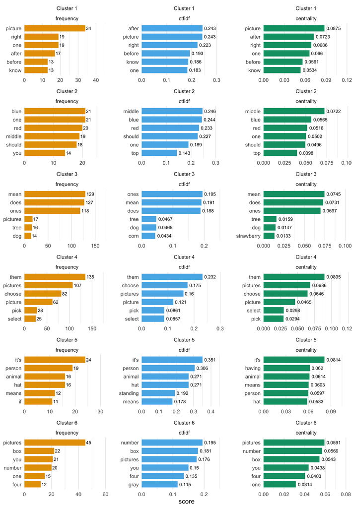

```r
plot(views)
```

With the attention view added as a fourth column:

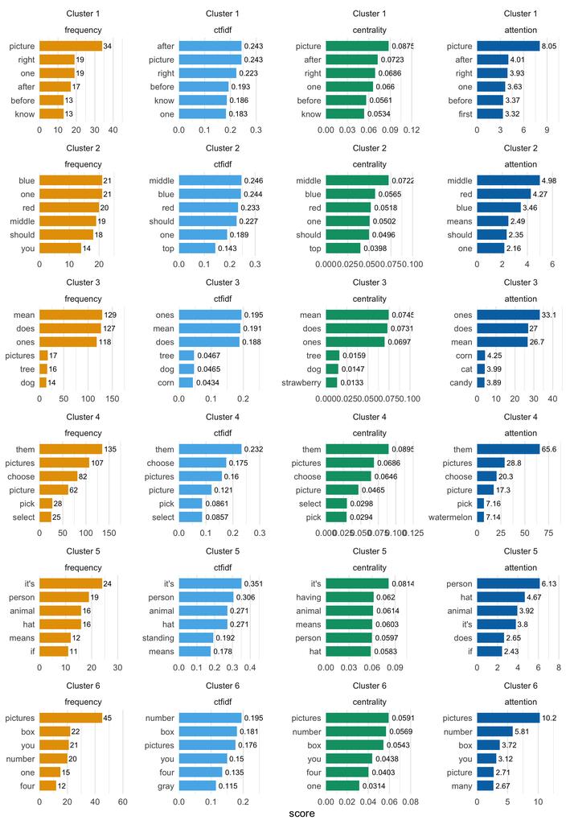

```r
four <- hg_keywords(hg_bag, topics, n = 6, scores = attention,
                    type = c("frequency", "ctfidf", "centrality"))
plot(four)
```

# Reading the disagreement

Where the columns agree, the topic owns its vocabulary: read the choose-a-picture panel (“them”, “choose”, “pick”, “select”) across the row. Where they disagree, each score is telling you something different. Frequency promotes words the whole corpus shares (“one”, “you”); c-TF-IDF demotes them and surfaces the topic’s own terms (“middle”, “top”, “gray”); centrality picks the words that co-occur with the most other words inside the topic, which favours the hub of a template (“picture”, “pictures”); attention is whatever the classifier found diagnostic for the topic label, and summed per topic it stays close to frequency (the correlation above), so read it as a frequency count re-weighted by what the classifier used. None is *the* keyword list. A topic is characterised by the set, and the figure is the compact way to read the set.

These word lists resemble the ones printed in the sbert vignette for the same 600 messages (its topic 1, for instance, is “picture”, “pictures”, “choose”). That is a reading of the two documents side by side, not a computed comparison: sbert’s topic model is not run here, and no agreement statistic between the two partitions is reported.